# General_Tasks_Group_07

Enis Ertekin Johannes XXX

2024-02-16

## Allgemeine Aufgaben

Zu Beginn werden erstmal die nötigen Pakte installiert:

## Library

```r
if(!require("install.load")){
  install.packages("install.load")
}
library(install.load)

install_load("readr", "dplyr","plotly", "ggplot2",  "knitr", "modeest","diptest","DescTools", "moments","fitdistrplus","tidyverse", "scales","nortest")
```

## Aufgabe 1

## a)

Als erstes werden die nötigen Daten importiert/geladen!

```r
Komponente_K7 <- read.csv2("DATA/Logistikverzug/Komponente_K7.csv")
Logistikverzug_K7 <- read.csv("DATA/Logistikverzug/Logistikverzug_K7.csv",sep=";")
```

In dieser Aufgabe untersuchen wir die Verteilung des Logistikverzugs der Komponente K7. Zunächst einmal werden die beiden eingelesenden Datasets zu Logistikverzug zusammengefügt. Dies passiert unter der Angabe der IDNummer.

```r
Logistikverzug <- merge(x = Komponente_K7[,c("IDNummer", "Produktionsdatum")], y = Logistikverzug_K7[ , c("IDNummer","Wareneingang")], by = "IDNummer")
```

Zur besseren Übersicht und zum Vergleiche wird nun das Datumsformat für das Wareneingang angepasst. Es wird das Format Y-m-d genutzt.

```r
Logistikverzug$Wareneingang <- as.Date(strptime(Logistikverzug$Wareneingang, format = "%d.%m.%Y"), format = "%Y-%m-%a")
```

Eine weitere Spalte wird angelegt, die den Differenz zwischen Produktionsdatum und Wareneingang bestimmt, hierbei wurden nach der Differenz der beiden Daten von Produktionsdatum und Wareneingang zusätzlich 2 Tage abgezogen, da der Hersteller 1 Tag für die Übergabe zur Logistikabteilung benötigt und dort ebenfalls 1 Tag benötigt wird für die Versandvorbereitung:

```r
Verzug <- as.integer(difftime(Logistikverzug$Wareneingang,Logistikverzug$Produktionsdatum,  units = "days")) -2
Logistikverzug <- mutate(Logistikverzug, Verzug)
```

Nun wird ein Histogramm mit den Verzugsdaten dargestellt:

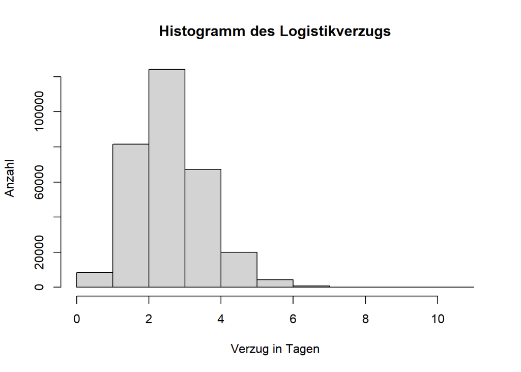

```r
hist(Verzug, breaks=10, main="Histogramm des Logistikverzugs", xlab="Verzug in Tagen", ylab="Anzahl")
```

Das Histogramm deutet darauf hin, dass die logistische Verzögerung einer Normalverteilung folgt. Ein Q-Q-Diagramm kann verwendet werden, um diese Annahme zu überprüfen. Der Q-Q Plot vergleicht die Daten des logistischen Verzugs mit den theoretischen Quantilen. Wenn die empirischen und die theoretischen Quantile der jeweiligen Verteilung nahe beieinander liegen, sind die empirischen Daten wie die angenommene Verteilung verteilt.

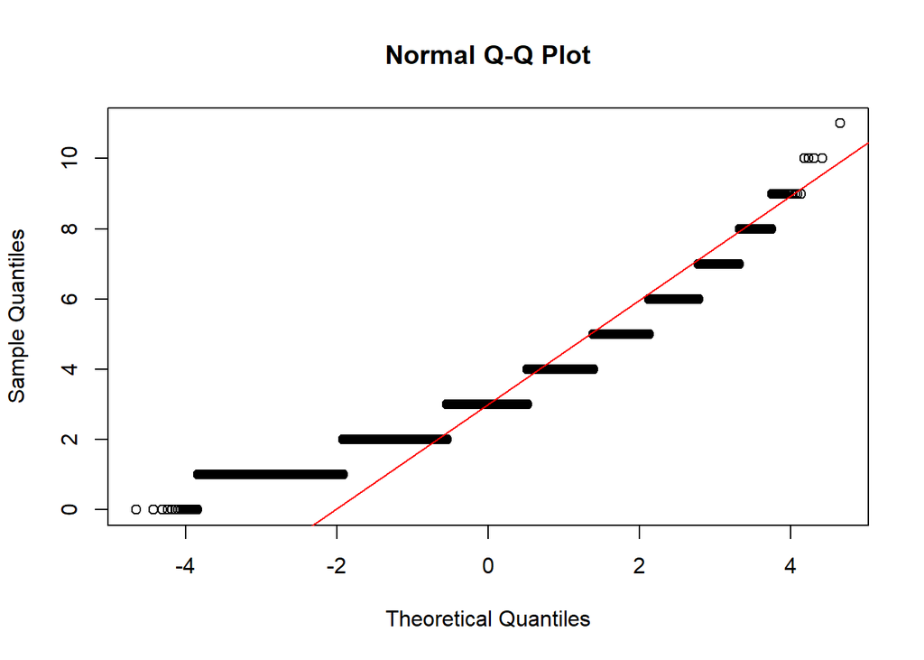

```r
qqnorm(Verzug)
qqline(Verzug, col="red")
```

## b)

Der minimale Verzug und der maximaler Verzug werden bestimmt durch:

```r
min(Logistikverzug$Verzug)
```

```
## [1] 0
```

Der Minimalwert beträgt damit 0 Tage.

```r
max(Logistikverzug$Verzug)
```

```
## [1] 11
```

Der Maximalwert beträgt damit 11 Tage.

## c)

Hier wird nun der Mittelwert des Logistiksverzuges bestimmt:

```r
mittelwert <- mean(Verzug)
```

Der Mittelwert des Verzuges liegt bei 3.080437 Tagen.

## d)

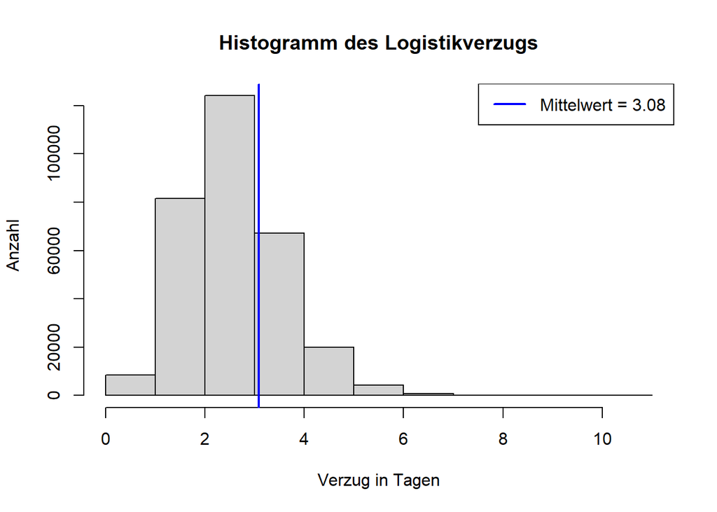

```r
hist(Verzug, breaks=10, main="Histogramm des Logistikverzugs", xlab="Verzug in Tagen", ylab="Anzahl")
abline(v = mittelwert, col = "blue", lwd = 2)
legend("topright", legend = paste("Mittelwert =", round(mittelwert, 2)), col = "blue", lwd = 2)
```

## Aufgabe 2

Frage: Warum ist es sinnvoll, die Ihnen bereitgestellten Daten in separaten Dateien abzulegen und nicht alles in einer riesigen Tabelle abzuspeichern (4 Argumente)? Wie nennt sich das zugrunde liegende Datenbankkonzept?

Das zugrundeliegende Datenbankkonzept wird als Beziehungsdatenbanksystem bezeichnet.Dieses Konzept hat mehrere Vorteile:

Geschwindigkeit

- Die Geschwindigkeit einer relationalen Datenbank ist im Vergleich zu anderen Datenbanktypen wesentlich höher.

Sicherheit

- Bestimmte Tabellen in einer relationalen Datenbank können vertraulich gemacht werden. Da Tabellen mit einem Benutzernamen und einem Passwort geschützt werden können, können nur autorisierte Benutzer auf diese Tabellen zugreifen und daran arbeiten.

Einfachheit

- Eine relationale Datenbank ist im Vergleich zu anderen Arten von Netzwerkmodellen sehr viel einfacher. Da sie frei von komplexer Strukturierung und Abfrageverarbeitung ist, erfordert sie keine komplexen Abfragen.

Korrektheit

- Alle Daten, die in relationalen Datenbanken gespeichert werden, sind nicht wiederholbar. Das bedeutet, dass sich die Daten nicht duplizieren und daher genau sind.

Zugänglichkeit

- Eine relationale Datenbank benötigt keinen speziellen Pfad für den Zugriff auf die Daten.

Mehrere Benutzer

- Mehrere Benutzer können gleichzeitig auf eine relationale Datenbank zugreifen.

## Aufgabe 3

Wie viele der Komponenten K7 landeten in Fahrzeugen, die in Wehr, Landkreis Waldshut zugelassen wurden?

Zunächst einmal werden die benötigten Dateien eingelesen:

```r
komponenten_OEM1_typ11 <- read_csv2("DATA/Fahrzeug/Bestandteile_Fahrzeuge_OEM1_Typ11.csv")
komponenten_OEM1_typ12 <- read_csv2("DATA/Fahrzeug/Bestandteile_Fahrzeuge_OEM1_Typ12.csv")
komponenten_OEM2_typ21 <- read_csv2("DATA/Fahrzeug/Bestandteile_Fahrzeuge_OEM2_Typ21.csv")
komponenten_OEM2_typ22 <- read_csv2("DATA/Fahrzeug/Bestandteile_Fahrzeuge_OEM2_Typ22.csv")
k7 <- as_tibble(read.table("DATA/Komponente/Komponente_K7.txt", sep = "\t", stringsAsFactors = FALSE))
zulassungen <- read_csv2("DATA/Zulassungen/Zulassungen_alle_Fahrzeuge.csv")
```

Nun werden die nötigen Spalten der Datein ID_Fahrzeug, ID_Karosserie rausgelesen und in ein übersichtlicheres Dataframe übernommmen:

```r
komponenten_OEM1_typ11_slim <- komponenten_OEM1_typ11 %>%
  dplyr::select(ID_Fahrzeug, ID_Karosserie)
komponenten_OEM1_typ12_slim <- komponenten_OEM1_typ12 %>%
  dplyr::select(ID_Fahrzeug, ID_Karosserie)
komponenten_OEM2_typ21_slim <- komponenten_OEM2_typ21 %>%
  dplyr::select(ID_Fahrzeug, ID_Karosserie)
komponenten_OEM2_typ22_slim <- komponenten_OEM2_typ22 %>%
  dplyr::select(ID_Fahrzeug, ID_Karosserie)

k7_slim <- k7 %>%
  dplyr::select(ID_Karosserie)

zulassungen_slim <- zulassungen %>%
  dplyr::select(IDNummer, Gemeinden, Zulassung) %>%
  rename(ID_Fahrzeug = IDNummer)
```

Jetzt werden alle vorherigen Dataframes zusammengesammmelt in ein Dataframe abgespeichert mit den dazugehörigen Daten:

```r
komponenten_total <- rbind(komponenten_OEM1_typ11_slim, komponenten_OEM1_typ12_slim, komponenten_OEM2_typ21_slim, komponenten_OEM2_typ22_slim)

final_data <- left_join(k7_slim, komponenten_total, by = "ID_Karosserie") %>%
  left_join(zulassungen_slim, by = "ID_Fahrzeug")
```

Abschließend kann nun aus dem Dataframe die Anzahl der Fahrzeuge gefiltert werden:

```r
fahrzeuge_k7_wehr <- filter(final_data, Gemeinden == "WEHR") %>%
  summarise(Amount_Cars_in_Wehr = n())
fahrzeuge_k7_wehr
```

```
## # A tibble: 1 × 1
##   Amount_Cars_in_Wehr
##                 <int>
## 1                   6
```

Es gibt 6 Fahrzeuge, die die Komponente K7 enthalten und in Wehr zugelassen wurden!

## Aufgabe 4

Welche Datentypen haben die Attribute der Zulassungstabelle „Zulassungen_aller_Fahrzeuge“? Erstellen Sie dazu eine Tabelle in Markdown.

Zunächst wird die Datei “Zulassungen_alle_Fahrzeuge” importiert:

```r
zulassungen <- read_csv2("DATA/Zulassungen/Zulassungen_alle_Fahrzeuge.csv")
```

```r
class(zulassungen$...1) #numeric
```

```
## [1] "numeric"
```

```r
class(zulassungen$IDNummer) #character
```

```
## [1] "character"
```

```r
class(zulassungen$Gemeinden) #character
```

```
## [1] "character"
```

```r
class(zulassungen$Zulassung) #date
```

```
## [1] "Date"
```

Die Tabelle mit allen Spaltennamen und Datentypen ist hier zu sehen:

Importiertes Dataframe

| Spalte | Datentypen |
| --- | --- |
| …1 | numeric |
| IDNummer | character |
| Gemeinden | character |
| Zulassung | Date |

## Aufgabe 5

Sie wollen Ihre Applikation veröffentlichen. Warum ist es gerade dann sinnvoll die Datensätze auf der Datenbank eines Servers abzulegen?

Verfügbarkeit:

- Ein Server ist immer verfügbarKunden können immer und von überall auf die Informationen zugreifen
- Ein eigener Computer ist ungeeignet, da nicht jeder auf die zugrunde liegenden Daten zugreifen kann

Rechenleistung:

- Ein Server hat in der Regel hardwaremäßig viel mehr Rechenleistung als lokale Computer
- Technische Probleme wie Überkapazitäten können vermieden werden.

Warum können Sie die Datensätze nicht auf Ihrem persönlichen Computer ablegen?

Menge der Daten:

- Sowohl die Datenmenge als auch die Datenanalyse erfordern eine große Speicherkapazität. Ein Personalcomputer ist unter Umständen nicht in der Lage, diese zu verarbeiten. Verlust von Daten
- Daten können auf einem Personalcomputer verloren gehen.

Sicherheit

- Die Verwendung eines Personalcomputers ist aus Sicherheitsgründen nicht zu empfehlen
- Der Zugriff auf einen Server kann besser kontrolliert werden
- Außerdem erlaubt die Hardware von Servern eine redundante Speicherung, was eine höhere Sicherheit gegen technische Ausfälle bietet.

Nennen Sie eine einfache Möglichkeit Ihre Applikation ihrem Kundenkreis zugänglich zu machen?

Eine gute Möglichkeit, Ihre Anwendung Ihren Kunden zur Verfügung zu stellen, ist die Bereitstellung über eine Webseite. Die Kunden können die Anwendung über das Internet mit einem Webbrowser nutzen.

## Aufgabe 6

Am 11.08.2010 hat es einen Unfall mit Fahrerflucht gegeben. Von dem Kennzeichen des Unfallwagens fehlt jede Spur. Die Polizei bittet Sie um Hilfe, da Sie für das Kraftfahrtbundesamt arbeiten und fragt, wo das Fahrzeug mit der Karosseriebauteilnummer „K7-114-1142-31“ zugelassen wurde.

```r
komponenten_mit_zulassungen <- left_join(zulassungen_slim, komponenten_total, by = "ID_Fahrzeug")


ort <- filter(komponenten_mit_zulassungen, ID_Karosserie == "K7-114-1142-31")

ort
```

```
## # A tibble: 1 × 4
##   ID_Fahrzeug Gemeinden        Zulassung  ID_Karosserie
##   <chr>       <chr>            <date>     <chr>
## 1 22-2-22-2   ALLENDORF (EDER) 2009-01-02 K7-114-1142-31
```

Das Fahrzeug mit der Kassoriebauteilnummer „K7-114-1142-31“ wurde in Allendorf (Eder) zugelassen.